# Codebook for Replication of the Epistemic Side‑Effect Effect (ESEE) in Polish on a Representative Sample

Bartosz Maćkiewicz, Marta Zaręba, Katarzyna Kuś, Katarzyna Paprzycka‑Hausman

```r
library(codebook)   # creates codebooks
library(readr)      # fast read_csv()

esee <- read_csv("../data/esee_in_polish_clean.csv")
```

```r
add_likert_labels <- function(x) {
  val_labels(x) <- c("-3 Strongly disagree" = -3,
                  "-2" = -2,
                  "-1" = -1,
                  "0" = 0,
                  "1" = 1,
                  "2" = 2,
                  "+3 Strongly agree" = 3)
  x
}

# Metadata
attributes(esee)$label <- "A Replication of the Epistemic Side-Effect Effect in Polish on a Representative Sample"
metadata(esee)$description        <- "Cleaned participant‑level data for the Polish replication of the Epistemic Side‑Effect Effect (ESEE)."
metadata(esee)$survey_repetition  <- "single"
metadata(esee)$identifier         <- "doi:10.17605/OSF.IO/6TVNH"
metadata(esee)$citation           <- "Zaręba, M., Kuś, K., Maćkiewicz, B., & Paprzycka-Hausman, K. (2025). A Replication of the Epistemic Side-Effect Effect in Polish on a Representative Sample. https://doi.org/10.17605/OSF.IO/6TVNH
"

# Variable labels
var_label(esee$ID)                  <- "Participant ID"
var_label(esee$survey_finish_time)  <- "Survey completion time (s)"
var_label(esee$sex)                 <- "Biological sex"
var_label(esee$sex2)                <- "Free‑text gender (only if sex = ‘Other’)"
var_label(esee$age)                 <- "Age bin (panel categories)"
var_label(esee$edu)                 <- "Highest completed education"
var_label(esee$year)                <- "Age in years"
var_label(esee$location)            <- "Place of residence (5 levels)"
var_label(esee$location2)           <- "Residence – mid split (20–49 k vs. 50–99 k)"
var_label(esee$location3)           <- "Residence – upper‑mid split (100–200 k vs. 200–500 k)"
var_label(esee$KLikert)             <- "CEO knew (Likert)"
var_label(esee$KBinary)             <- "CEO knew (forced choice)"
var_label(esee$KBinaryAll)          <- "CEO knew – composite (Yes/No/Neither)"
var_label(esee$KExpl)               <- "Justification (full text)"
var_label(esee$KExplSimple)         <- "Justification – coded (B/Q/R/O)"
var_label(esee$KExplOther)          <- "Justification (free text for `O(ther)` option)"
var_label(esee$KProfits)            <- "CEO knew profits increase"
var_label(esee$Int)                 <- "Intentionality – ‘intencjonalnie’"
var_label(esee$IntUmyślnie)         <- "Intentionality – ‘umyślnie’"
var_label(esee$IntCelowo)           <- "Intentionality – ‘celowo’"
var_label(esee$IntŚwiadomie)        <- "Intentionality – ‘świadomie’"
var_label(esee$Intention)           <- "Intention – ‘miał intencję’"
var_label(esee$BSądził)             <- "Belief – ‘sądził’"
var_label(esee$BPrzekonany)         <- "Belief – ‘był przekonany’"
var_label(esee$Aware)               <- "Awareness – ‘był świadomy’"
var_label(esee$Reasons)             <- "Reasons – ‘miał powody’"
var_label(esee$Condition)           <- "Experimental condition (Harm/Help)"
var_label(esee$Scale)               <- "Response format (LIK/FC)"
var_label(esee$Form)                <- "Item formulation (AG/PR/ST)"

# Value labels for categorical variables
esee$sex <- factor(
  esee$sex,
  levels  = c("Kobieta", "Mężczyzna", "Inna", "Nie chcę udzielać odpowiedzi"),
  labels  = c("Female", "Male", "Other", "Prefer not to say")
)

esee$edu <- factor(
  esee$edu,
  levels = c(
    "Podstawowe",
    "Zawodowe lub policealne",
    "Średnie",
    "Wyższe licencjackie lub inżynierskie",
    "Wyższe magisterskie",
    "Doktorat lub więcej"
  ),
  labels = c(
    "Primary education",
    "Vocational / post‑secondary diploma",
    "Secondary education (high‑school)",
    "Bachelor’s / Engineering",
    "Master’s (MA/MSc)",
    "Doctorate or higher"
  ),
  ordered = TRUE
)

esee$Condition <- factor(esee$Condition, levels = c("Harm", "Help"))
esee$Scale     <- factor(esee$Scale,     levels = c("LIK", "FC"))
esee$Form      <- factor(esee$Form,      levels = c("AG", "PR", "ST"))
esee$KExpl     <- factor(esee$KExpl)

# Likert value labels for all 7‑point items
likert_vars <- c(
  "KLikert", "KProfits",
  "Int", "IntUmyślnie", "IntCelowo", "IntŚwiadomie", "Intention",
  "BSądził", "BPrzekonany", "Aware", "Reasons"
)
esee[likert_vars] <- lapply(esee[likert_vars], add_likert_labels)

# Build codebook
codebook(esee)
```

### Metadata

#### Description

**Dataset name**: esee

Cleaned participant‑level data for the Polish replication of the Epistemic Side‑Effect Effect (ESEE).

**Metadata for search engines**

- **Citation**: Zaręba, M., Kuś, K., Maćkiewicz, B., & Paprzycka-Hausman, K. (2025). A Replication of the Epistemic Side-Effect Effect in Polish on a Representative Sample. https://doi.org/10.17605/OSF.IO/6TVNH
- **Identifier**: [doi:10.17605/OSF.IO/6TVNH](https://dx.doi.org/10.17605/OSF.IO/6TVNH)
- **Date published**: 2025-04-23

| x |
| --- |
| single |

| x |
| --- |
| ID |
| survey_finish_time |
| sex |
| sex2 |
| age |
| year |
| location |
| location2 |
| location3 |
| KLikert |
| KBinary |
| KBinaryAll |
| KExpl |
| KExplSimple |
| KExplOther |
| KProfits |
| Int |
| IntUmyślnie |
| IntCelowo |
| IntŚwiadomie |
| Intention |
| BSądził |
| BPrzekonany |
| Aware |
| Reasons |
| Condition |
| Scale |
| Form |
| edu |

## Variables

### ID

Participant ID

#### Distribution

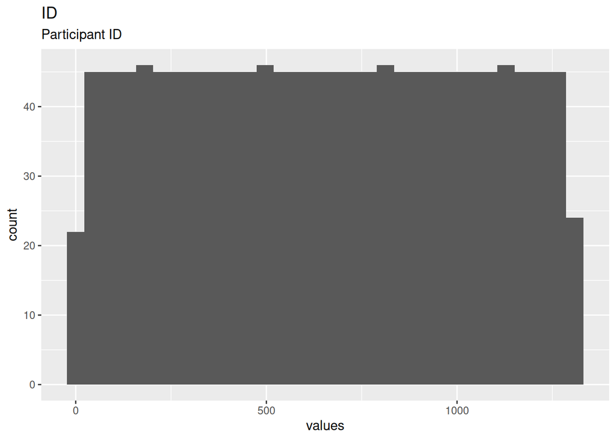

Distribution of values for ID

0 missing values.

#### Summary statistics

| name | label | data_type | n_missing | complete_rate | min | median | max | mean | sd | hist |
| --- | --- | --- | --- | --- | --- | --- | --- | --- | --- | --- |
| ID | Participant ID | numeric | 0 | 1 | 1 | 656 | 1310 | 655.5 | 378.3087 | ▇▇▇▇▇ |

### survey_finish_time

Survey completion time (s)

#### Distribution

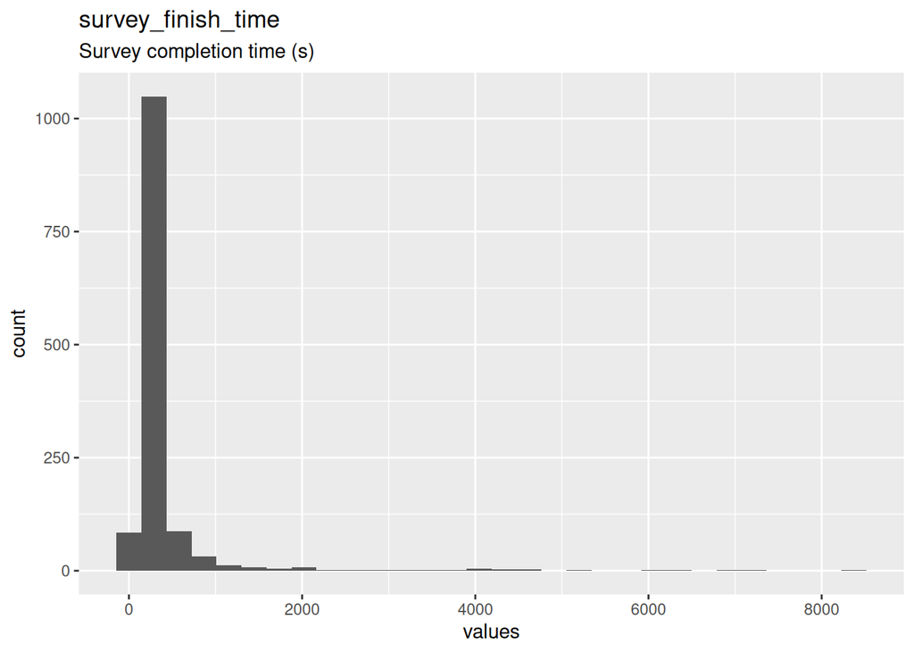

Distribution of values for survey_finish_time

0 missing values.

#### Summary statistics

| name | label | data_type | n_missing | complete_rate | min | median | max | mean | sd | hist |
| --- | --- | --- | --- | --- | --- | --- | --- | --- | --- | --- |
| survey_finish_time | Survey completion time (s) | numeric | 0 | 1 | 109 | 239 | 8483 | 383.2168 | 648.1145 | ▇▁▁▁▁ |

### sex

#### Distribution

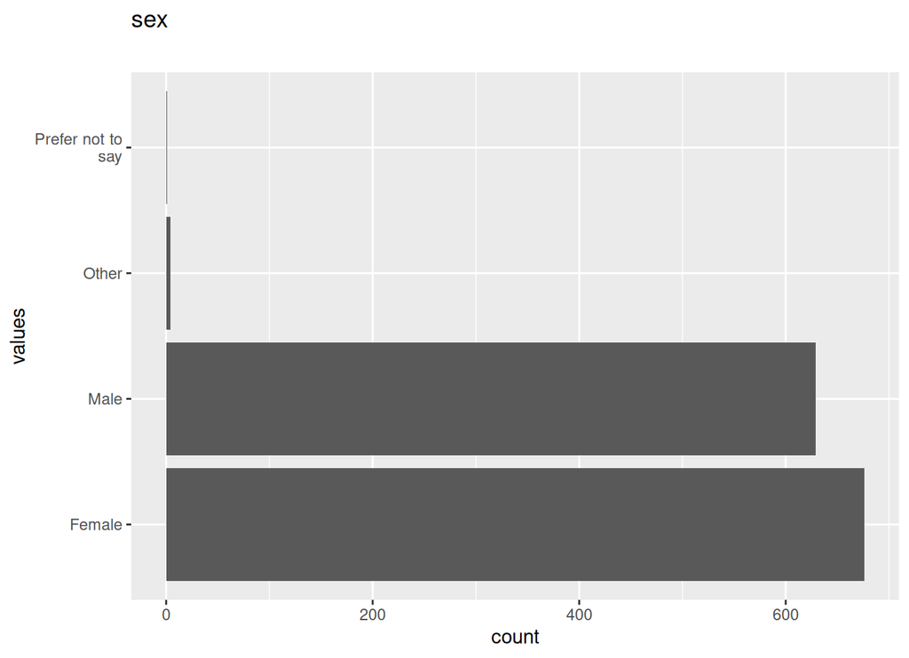

Distribution of values for sex

0 missing values.

#### Summary statistics

| name | data_type | ordered | value_labels | n_missing | complete_rate | n_unique | top_counts | label |
| --- | --- | --- | --- | --- | --- | --- | --- | --- |
| sex | factor | FALSE | 1. Female, 2. Male, 3. Other, 4. Prefer not to say | 0 | 1 | 4 | Fem: 676, Mal: 629, Oth: 4, Pre: 1 | NA |

### sex2

Free‑text gender (only if sex = ‘Other’)

#### Distribution

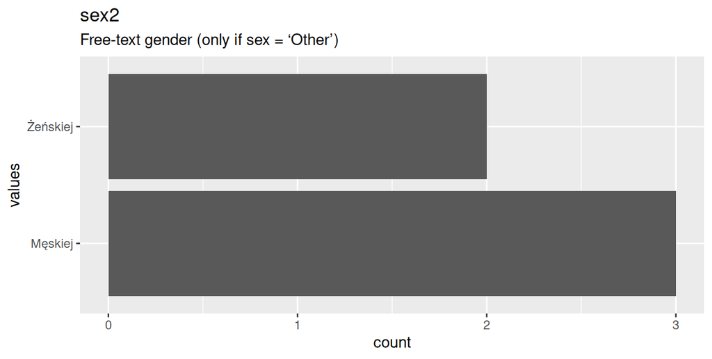

Distribution of values for sex2

1305 missing values.

#### Summary statistics

| name | label | data_type | n_missing | complete_rate | n_unique | empty | min | max | whitespace |
| --- | --- | --- | --- | --- | --- | --- | --- | --- | --- |
| sex2 | Free‑text gender (only if sex = ‘Other’) | character | 1305 | 0.0038168 | 2 | 0 | 7 | 8 | 0 |

### age

Age bin (panel categories)

#### Distribution

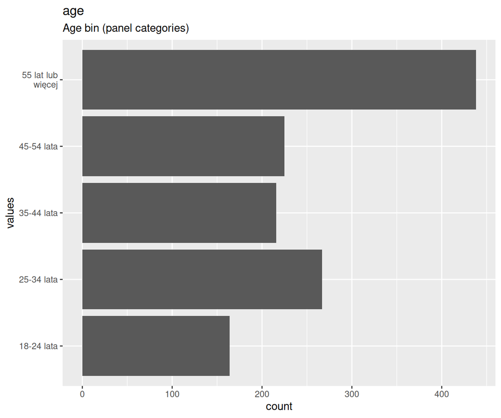

Distribution of values for age

0 missing values.

#### Summary statistics

| name | label | data_type | n_missing | complete_rate | n_unique | empty | min | max | whitespace |
| --- | --- | --- | --- | --- | --- | --- | --- | --- | --- |
| age | Age bin (panel categories) | character | 0 | 1 | 5 | 0 | 10 | 17 | 0 |

### year

Age in years

#### Distribution

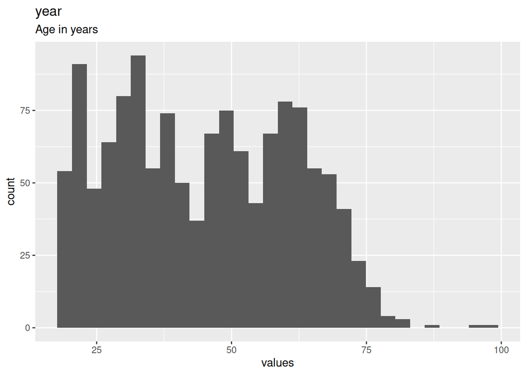

Distribution of values for year

0 missing values.

#### Summary statistics

| name | label | data_type | n_missing | complete_rate | min | median | max | mean | sd | hist |
| --- | --- | --- | --- | --- | --- | --- | --- | --- | --- | --- |
| year | Age in years | numeric | 0 | 1 | 18 | 45 | 97 | 45.13511 | 16.4137 | ▇▇▇▃▁ |

### location

Place of residence (5 levels)

#### Distribution

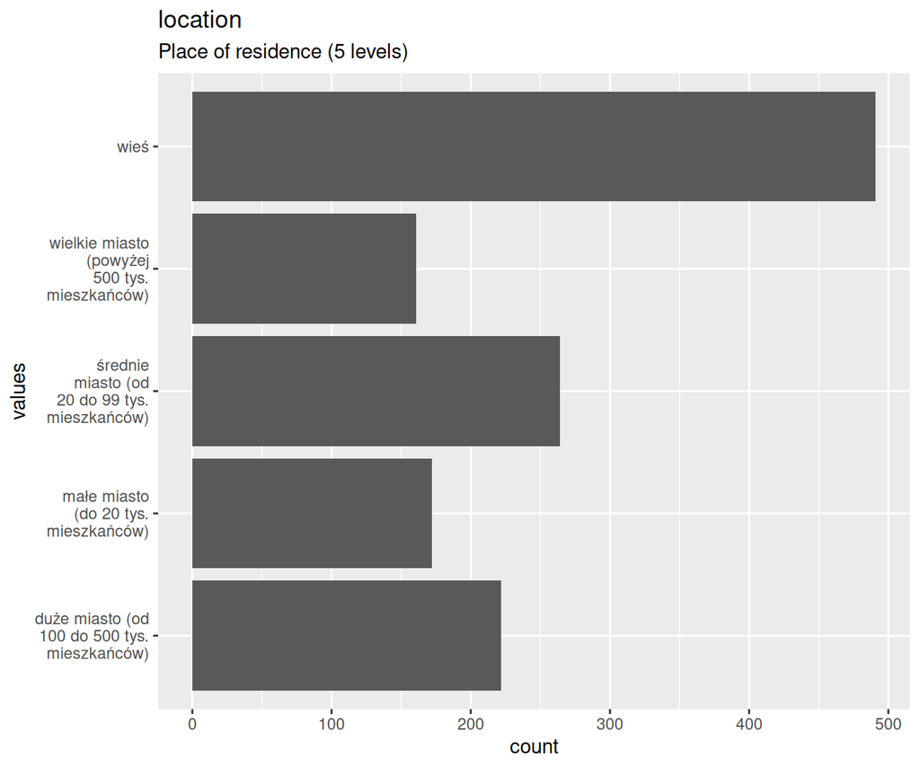

Distribution of values for location

0 missing values.

#### Summary statistics

| name | label | data_type | n_missing | complete_rate | n_unique | empty | min | max | whitespace |
| --- | --- | --- | --- | --- | --- | --- | --- | --- | --- |
| location | Place of residence (5 levels) | character | 0 | 1 | 5 | 0 | 4 | 45 | 0 |

### location2

Residence – mid split (20–49 k vs. 50–99 k)

#### Distribution

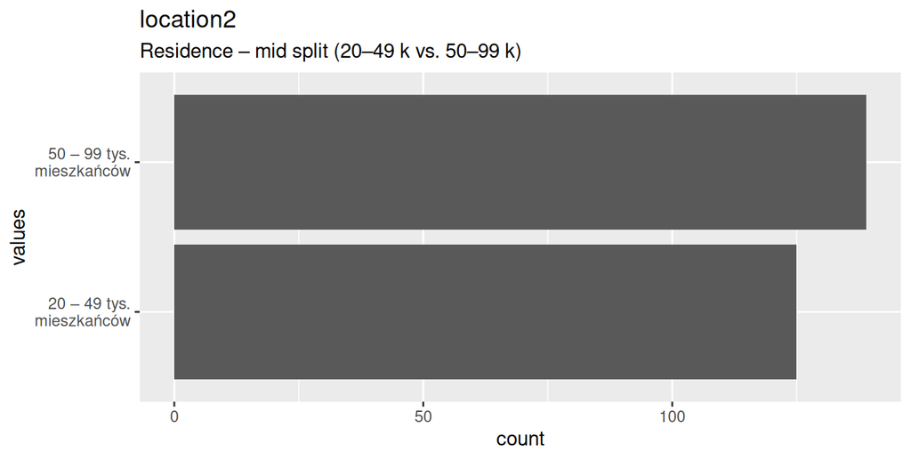

Distribution of values for location2

1046 missing values.

#### Summary statistics

| name | label | data_type | n_missing | complete_rate | n_unique | empty | min | max | whitespace |
| --- | --- | --- | --- | --- | --- | --- | --- | --- | --- |
| location2 | Residence – mid split (20–49 k vs. 50–99 k) | character | 1046 | 0.2015267 | 2 | 0 | 24 | 24 | 0 |

### location3

Residence – upper‑mid split (100–200 k vs. 200–500 k)

#### Distribution

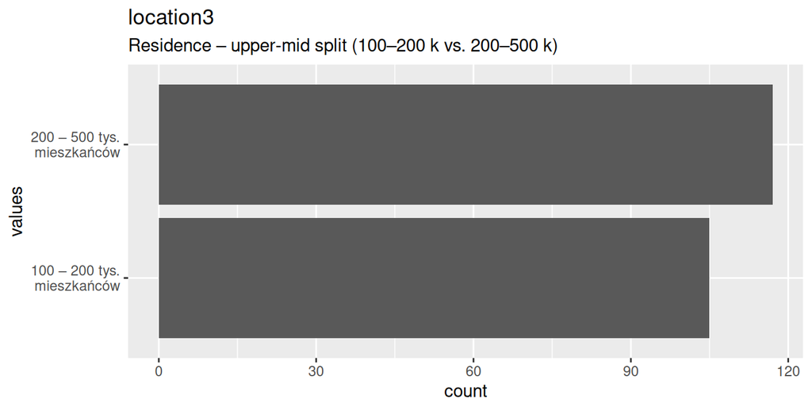

Distribution of values for location3

1088 missing values.

#### Summary statistics

| name | label | data_type | n_missing | complete_rate | n_unique | empty | min | max | whitespace |
| --- | --- | --- | --- | --- | --- | --- | --- | --- | --- |
| location3 | Residence – upper‑mid split (100–200 k vs. 200–500 k) | character | 1088 | 0.1694656 | 2 | 0 | 26 | 26 | 0 |

### KLikert

CEO knew (Likert)

#### Distribution

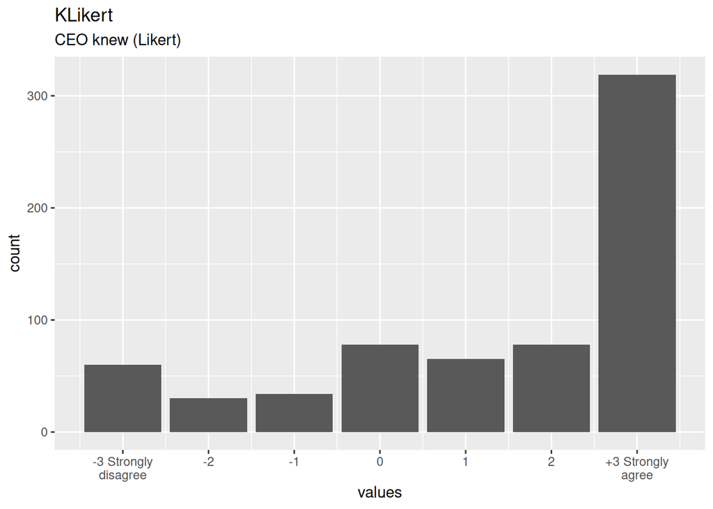

Distribution of values for KLikert

646 missing values.

#### Summary statistics

| name | label | data_type | n_missing | complete_rate | min | median | max | mean | sd | n_value_labels | hist |
| --- | --- | --- | --- | --- | --- | --- | --- | --- | --- | --- | --- |
| KLikert | CEO knew (Likert) | haven_labelled | 646 | 0.5068702 | -3 | 2 | 3 | 1.361446 | 2.022219 | 7 | ▂▁▁▂▁▂▂▇ |

#### Value labels

Response choices

| name | value |
| --- | --- |
| -3 Strongly disagree | -3 |
| -2 | -2 |
| -1 | -1 |
| 0 | 0 |
| 1 | 1 |
| 2 | 2 |
| +3 Strongly agree | 3 |

### KBinary

CEO knew (forced choice)

#### Distribution

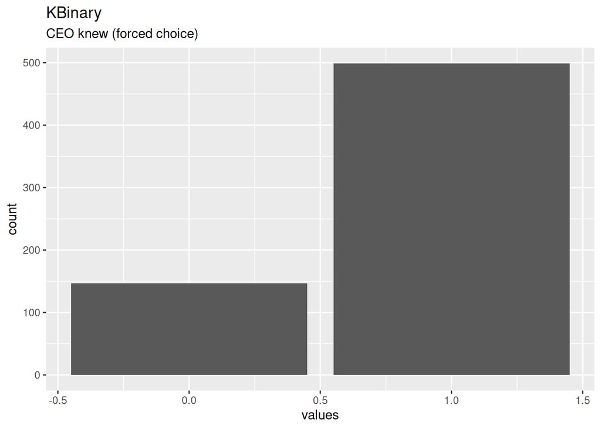

Distribution of values for KBinary

664 missing values.

#### Summary statistics

| name | label | data_type | n_missing | complete_rate | min | median | max | mean | sd | hist |
| --- | --- | --- | --- | --- | --- | --- | --- | --- | --- | --- |
| KBinary | CEO knew (forced choice) | numeric | 664 | 0.4931298 | 0 | 1 | 1 | 0.7724458 | 0.4195781 | ▂▁▁▁▇ |

### KBinaryAll

CEO knew – composite (Yes/No/Neither)

#### Distribution

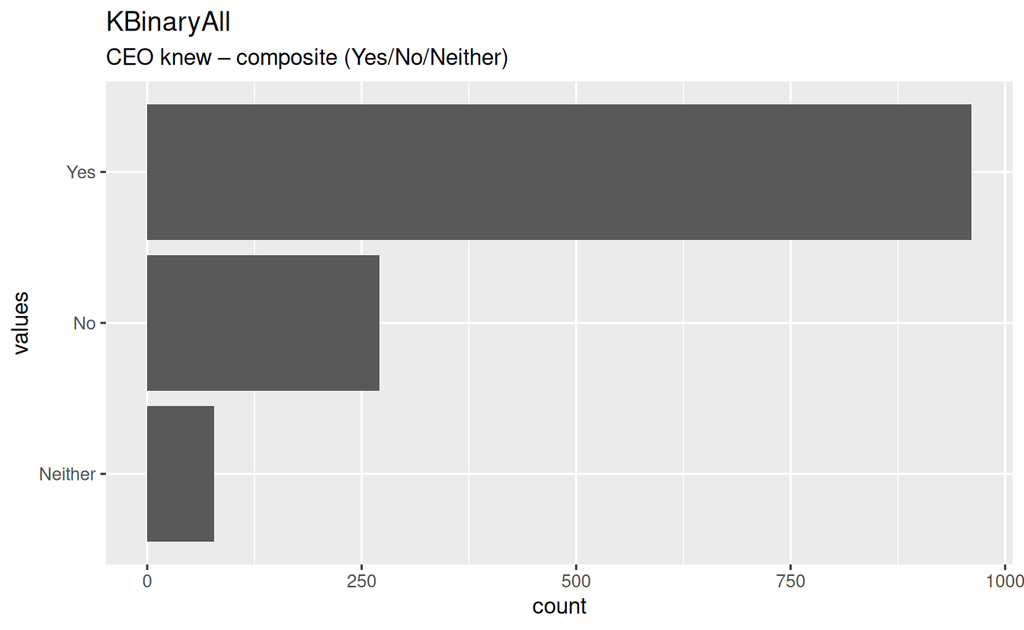

Distribution of values for KBinaryAll

0 missing values.

#### Summary statistics

| name | label | data_type | n_missing | complete_rate | n_unique | empty | min | max | whitespace |
| --- | --- | --- | --- | --- | --- | --- | --- | --- | --- |
| KBinaryAll | CEO knew – composite (Yes/No/Neither) | character | 0 | 1 | 3 | 0 | 2 | 7 | 0 |

### KExpl

#### Distribution

```
## 52  unique, categorical values, so not shown.
```

0 missing values.

#### Summary statistics

| name | data_type | ordered | value_labels | n_missing | complete_rate | n_unique | top_counts | label |
| --- | --- | --- | --- | --- | --- | --- | --- | --- |
| KExpl | factor | FALSE | 1. Dyrektor był przekonany, że pomoże środowisku., 2. Dyrektor był przekonany, że stan środowiska się pogorszy., 3. Dyrektor był przekonany, że stan środowiska się polepszy., 4. Dyrektor był przekonan… | 0 | 1 | 52 | Dyr: 120, Dyr: 120, Dyr: 109, Dyr: 92 | NA |

### KExplSimple

Justification – coded (B/Q/R/O)

#### Distribution

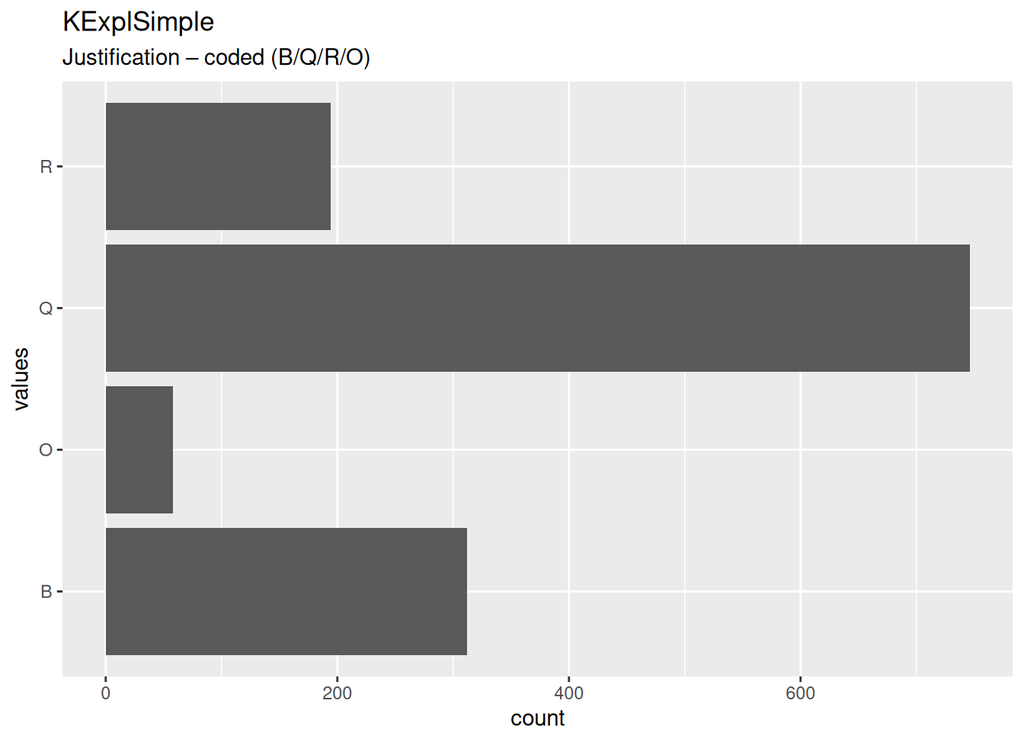

Distribution of values for KExplSimple

0 missing values.

#### Summary statistics

| name | label | data_type | n_missing | complete_rate | n_unique | empty | min | max | whitespace |
| --- | --- | --- | --- | --- | --- | --- | --- | --- | --- |
| KExplSimple | Justification – coded (B/Q/R/O) | character | 0 | 1 | 4 | 0 | 1 | 1 | 0 |

### KExplOther

Justification (free text for `O(ther)` option)

#### Distribution

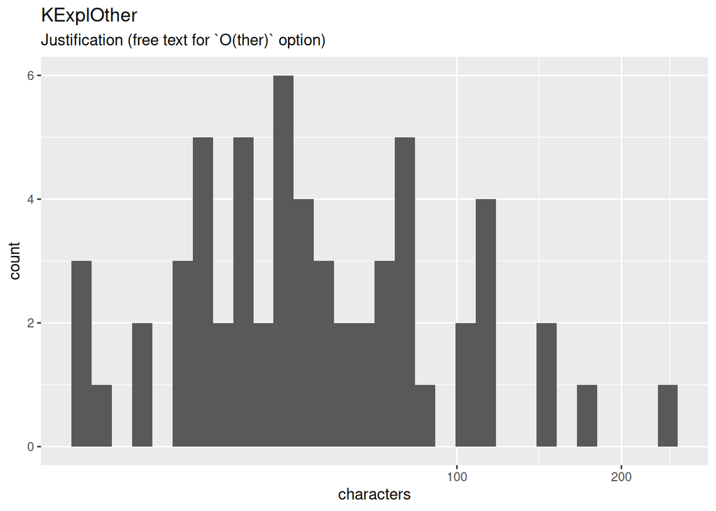

Distribution of values for KExplOther

1251 missing values.

#### Summary statistics

| name | label | data_type | n_missing | complete_rate | n_unique | empty | min | max | whitespace |
| --- | --- | --- | --- | --- | --- | --- | --- | --- | --- |
| KExplOther | Justification (free text for `O(ther)` option) | character | 1251 | 0.0450382 | 59 | 0 | 20 | 243 | 0 |

### KProfits

CEO knew profits increase

#### Distribution

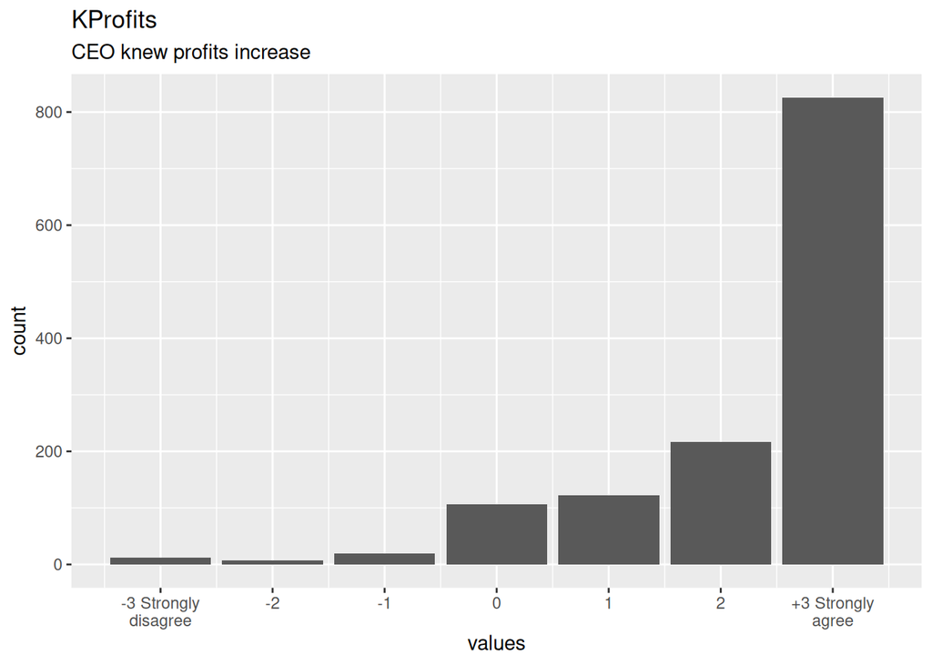

Distribution of values for KProfits

0 missing values.

#### Summary statistics

| name | label | data_type | n_missing | complete_rate | min | median | max | mean | sd | n_value_labels | hist |
| --- | --- | --- | --- | --- | --- | --- | --- | --- | --- | --- | --- |
| KProfits | CEO knew profits increase | haven_labelled | 0 | 1 | -3 | 3 | 3 | 2.263359 | 1.194634 | 7 | ▁▁▁▁▁▁▂▇ |

#### Value labels

Response choices

| name | value |
| --- | --- |
| -3 Strongly disagree | -3 |
| -2 | -2 |
| -1 | -1 |
| 0 | 0 |
| 1 | 1 |
| 2 | 2 |
| +3 Strongly agree | 3 |

### Int

Intentionality – ‘intencjonalnie’

#### Distribution

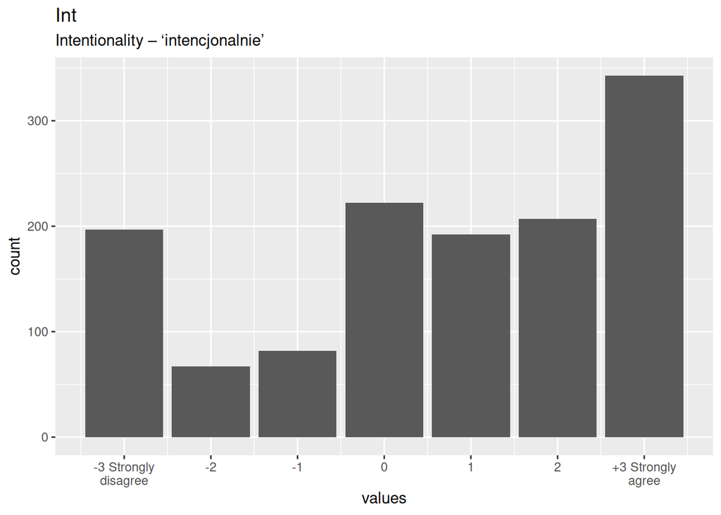

Distribution of values for Int

0 missing values.

#### Summary statistics

| name | label | data_type | n_missing | complete_rate | min | median | max | mean | sd | n_value_labels | hist |
| --- | --- | --- | --- | --- | --- | --- | --- | --- | --- | --- | --- |
| Int | Intentionality – ‘intencjonalnie’ | haven_labelled | 0 | 1 | -3 | 1 | 3 | 0.6320611 | 2.087954 | 7 | ▅▂▂▅▁▅▅▇ |

#### Value labels

Response choices

| name | value |
| --- | --- |
| -3 Strongly disagree | -3 |
| -2 | -2 |
| -1 | -1 |
| 0 | 0 |
| 1 | 1 |
| 2 | 2 |
| +3 Strongly agree | 3 |

### IntUmyślnie

Intentionality – ‘umyślnie’

#### Distribution

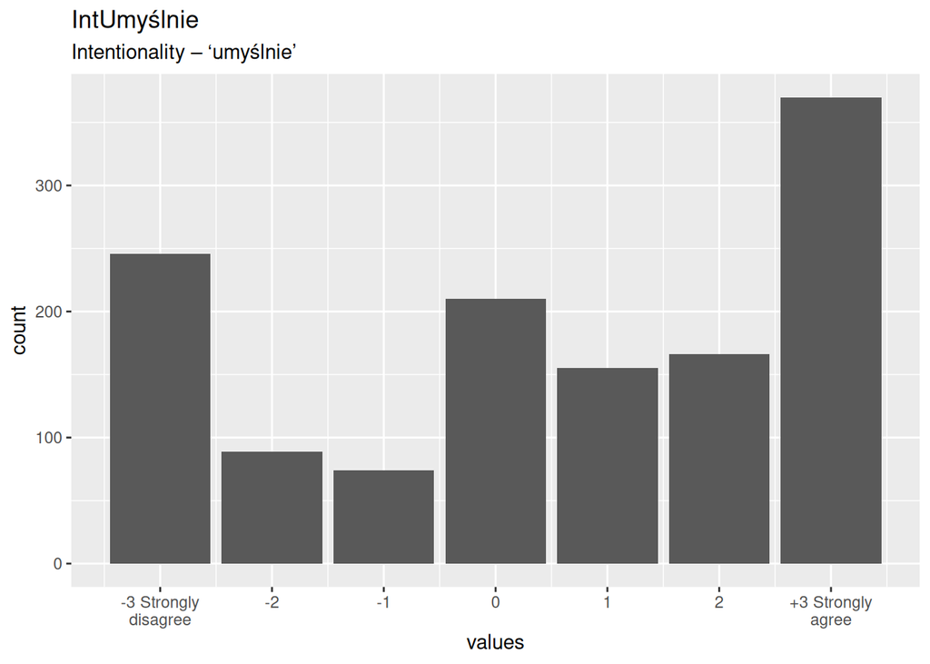

Distribution of values for IntUmyślnie

0 missing values.

#### Summary statistics

| name | label | data_type | n_missing | complete_rate | min | median | max | mean | sd | n_value_labels | hist |
| --- | --- | --- | --- | --- | --- | --- | --- | --- | --- | --- | --- |
| IntUmyślnie | Intentionality – ‘umyślnie’ | haven_labelled | 0 | 1 | -3 | 1 | 3 | 0.4633588 | 2.230379 | 7 | ▅▂▂▅▁▃▃▇ |

#### Value labels

Response choices

| name | value |
| --- | --- |
| -3 Strongly disagree | -3 |
| -2 | -2 |
| -1 | -1 |
| 0 | 0 |
| 1 | 1 |
| 2 | 2 |
| +3 Strongly agree | 3 |

### IntCelowo

Intentionality – ‘celowo’

#### Distribution

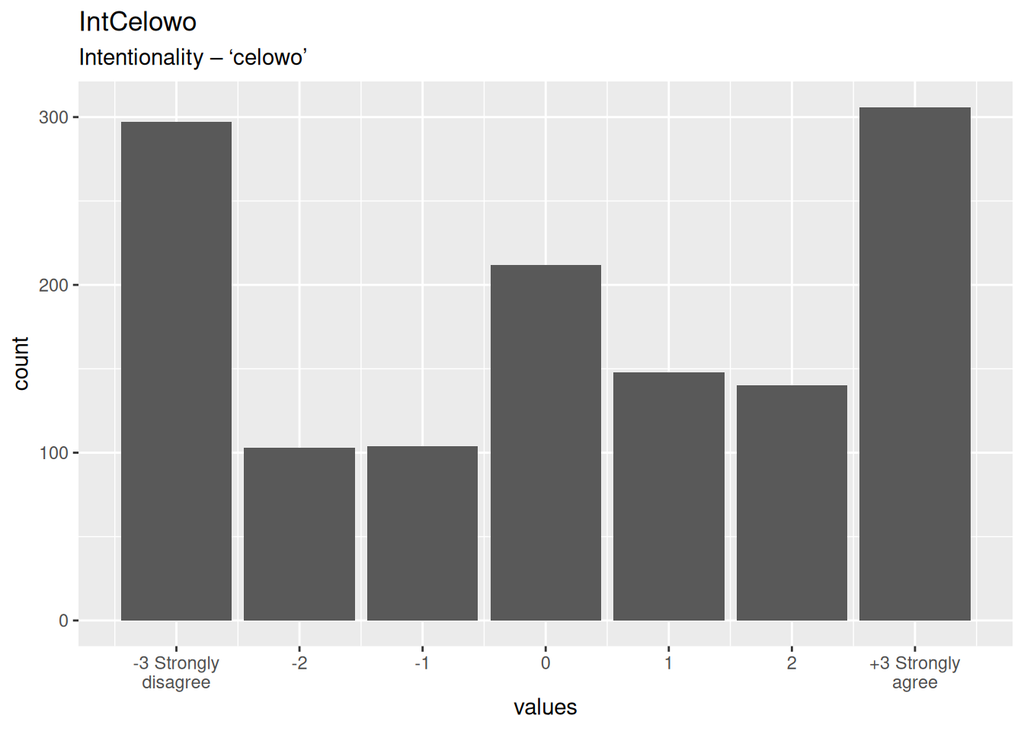

Distribution of values for IntCelowo

0 missing values.

#### Summary statistics

| name | label | data_type | n_missing | complete_rate | min | median | max | mean | sd | n_value_labels | hist |
| --- | --- | --- | --- | --- | --- | --- | --- | --- | --- | --- | --- |
| IntCelowo | Intentionality – ‘celowo’ | haven_labelled | 0 | 1 | -3 | 0 | 3 | 0.110687 | 2.251381 | 7 | ▇▃▃▆▁▃▃▇ |

#### Value labels

Response choices

| name | value |
| --- | --- |
| -3 Strongly disagree | -3 |
| -2 | -2 |
| -1 | -1 |
| 0 | 0 |
| 1 | 1 |
| 2 | 2 |
| +3 Strongly agree | 3 |

### IntŚwiadomie

Intentionality – ‘świadomie’

#### Distribution

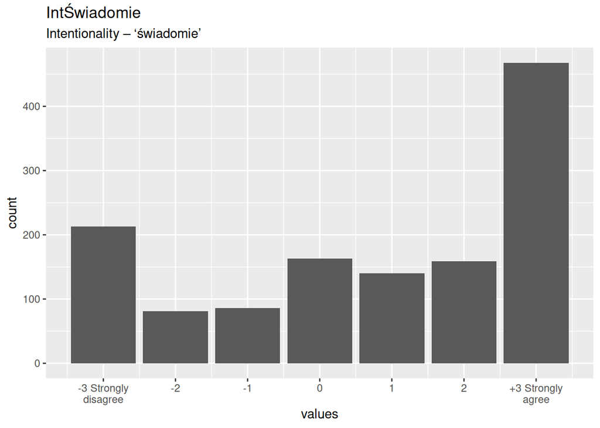

Distribution of values for IntŚwiadomie

0 missing values.

#### Summary statistics

| name | label | data_type | n_missing | complete_rate | min | median | max | mean | sd | n_value_labels | hist |
| --- | --- | --- | --- | --- | --- | --- | --- | --- | --- | --- | --- |
| IntŚwiadomie | Intentionality – ‘świadomie’ | haven_labelled | 0 | 1 | -3 | 1 | 3 | 0.7442748 | 2.243628 | 7 | ▃▂▂▃▁▂▃▇ |

#### Value labels

Response choices

| name | value |
| --- | --- |
| -3 Strongly disagree | -3 |
| -2 | -2 |
| -1 | -1 |
| 0 | 0 |
| 1 | 1 |
| 2 | 2 |
| +3 Strongly agree | 3 |

### Intention

Intention – ‘miał intencję’

#### Distribution

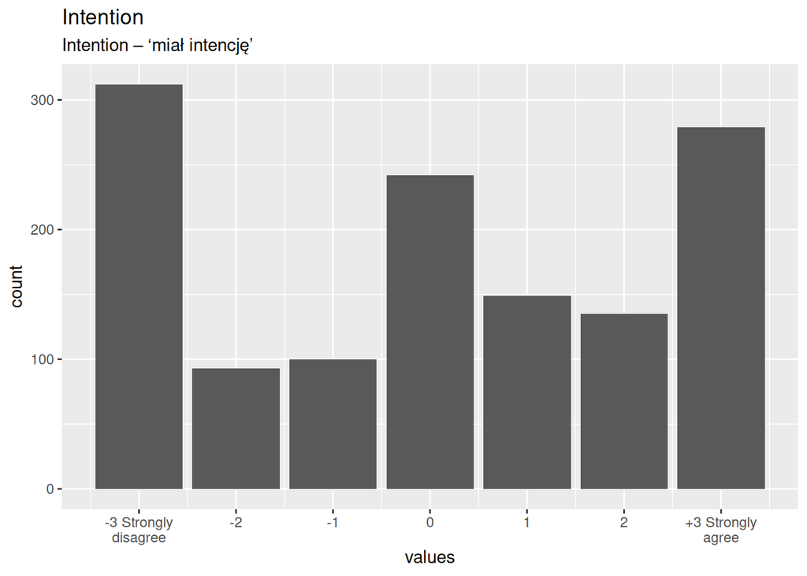

Distribution of values for Intention

0 missing values.

#### Summary statistics

| name | label | data_type | n_missing | complete_rate | min | median | max | mean | sd | n_value_labels | hist |
| --- | --- | --- | --- | --- | --- | --- | --- | --- | --- | --- | --- |
| Intention | Intention – ‘miał intencję’ | haven_labelled | 0 | 1 | -3 | 0 | 3 | 0.0259542 | 2.224785 | 7 | ▇▂▂▆▁▃▃▇ |

#### Value labels

Response choices

| name | value |
| --- | --- |
| -3 Strongly disagree | -3 |
| -2 | -2 |
| -1 | -1 |
| 0 | 0 |
| 1 | 1 |
| 2 | 2 |
| +3 Strongly agree | 3 |

### BSądził

Belief – ‘sądził’

#### Distribution

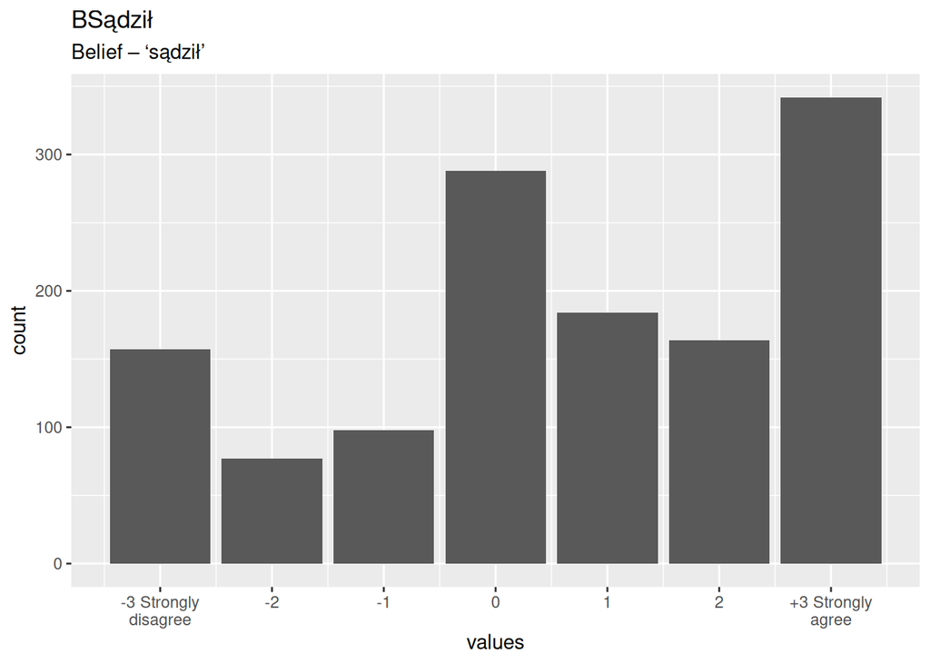

Distribution of values for BSądził

0 missing values.

#### Summary statistics

| name | label | data_type | n_missing | complete_rate | min | median | max | mean | sd | n_value_labels | hist |
| --- | --- | --- | --- | --- | --- | --- | --- | --- | --- | --- | --- |
| BSądził | Belief – ‘sądził’ | haven_labelled | 0 | 1 | -3 | 1 | 3 | 0.6221374 | 1.998846 | 7 | ▃▂▂▇▁▅▃▇ |

#### Value labels

Response choices

| name | value |
| --- | --- |
| -3 Strongly disagree | -3 |
| -2 | -2 |
| -1 | -1 |
| 0 | 0 |
| 1 | 1 |
| 2 | 2 |
| +3 Strongly agree | 3 |

### BPrzekonany

Belief – ‘był przekonany’

#### Distribution

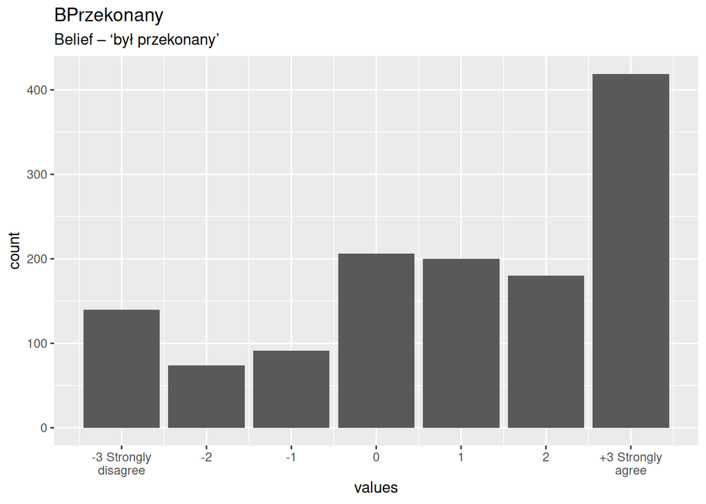

Distribution of values for BPrzekonany

0 missing values.

#### Summary statistics

| name | label | data_type | n_missing | complete_rate | min | median | max | mean | sd | n_value_labels | hist |
| --- | --- | --- | --- | --- | --- | --- | --- | --- | --- | --- | --- |
| BPrzekonany | Belief – ‘był przekonany’ | haven_labelled | 0 | 1 | -3 | 1 | 3 | 0.8839695 | 2.014911 | 7 | ▃▂▂▃▁▃▃▇ |

#### Value labels

Response choices

| name | value |
| --- | --- |
| -3 Strongly disagree | -3 |
| -2 | -2 |
| -1 | -1 |
| 0 | 0 |
| 1 | 1 |
| 2 | 2 |
| +3 Strongly agree | 3 |

### Aware

Awareness – ‘był świadomy’

#### Distribution

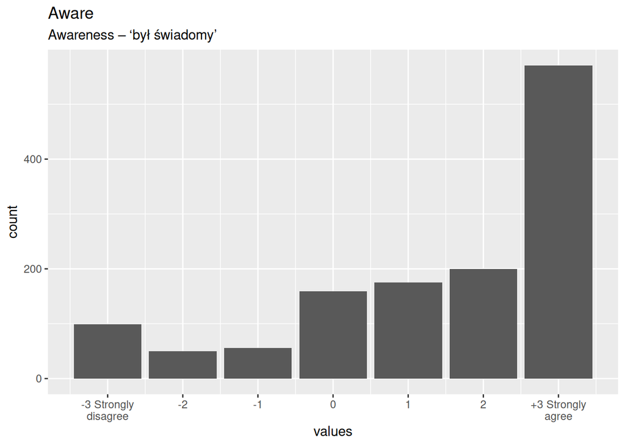

Distribution of values for Aware

0 missing values.

#### Summary statistics

| name | label | data_type | n_missing | complete_rate | min | median | max | mean | sd | n_value_labels | hist |
| --- | --- | --- | --- | --- | --- | --- | --- | --- | --- | --- | --- |
| Aware | Awareness – ‘był świadomy’ | haven_labelled | 0 | 1 | -3 | 2 | 3 | 1.400763 | 1.892973 | 7 | ▂▁▁▂▁▂▃▇ |

#### Value labels

Response choices

| name | value |
| --- | --- |
| -3 Strongly disagree | -3 |
| -2 | -2 |
| -1 | -1 |
| 0 | 0 |
| 1 | 1 |
| 2 | 2 |
| +3 Strongly agree | 3 |

### Reasons

Reasons – ‘miał powody’

#### Distribution

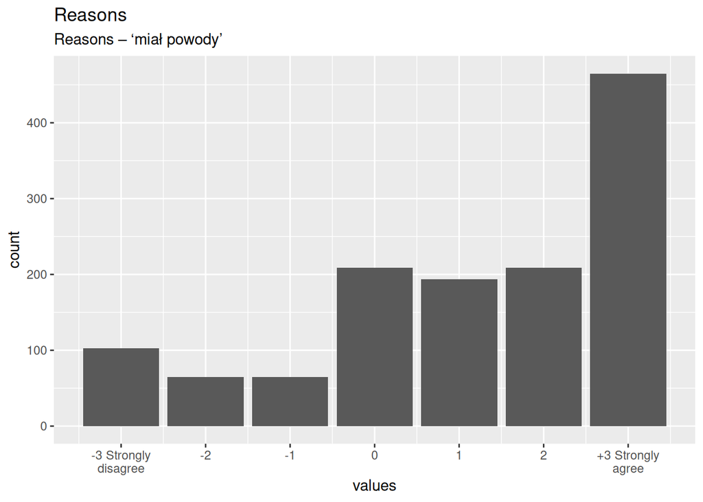

Distribution of values for Reasons

0 missing values.

#### Summary statistics

| name | label | data_type | n_missing | complete_rate | min | median | max | mean | sd | n_value_labels | hist |
| --- | --- | --- | --- | --- | --- | --- | --- | --- | --- | --- | --- |
| Reasons | Reasons – ‘miał powody’ | haven_labelled | 0 | 1 | -3 | 2 | 3 | 1.147328 | 1.90343 | 7 | ▂▁▁▃▁▃▃▇ |

#### Value labels

Response choices

| name | value |
| --- | --- |
| -3 Strongly disagree | -3 |
| -2 | -2 |
| -1 | -1 |
| 0 | 0 |
| 1 | 1 |
| 2 | 2 |
| +3 Strongly agree | 3 |

### Condition

#### Distribution

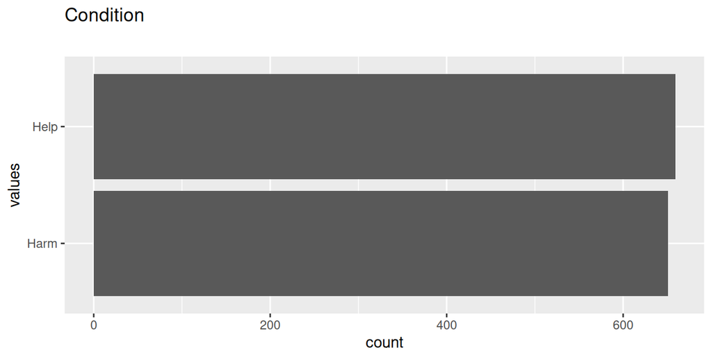

Distribution of values for Condition

0 missing values.

#### Summary statistics

| name | data_type | ordered | value_labels | n_missing | complete_rate | n_unique | top_counts | label |
| --- | --- | --- | --- | --- | --- | --- | --- | --- |
| Condition | factor | FALSE | 1. Harm, 2. Help | 0 | 1 | 2 | Hel: 659, Har: 651 | NA |

### Scale

#### Distribution

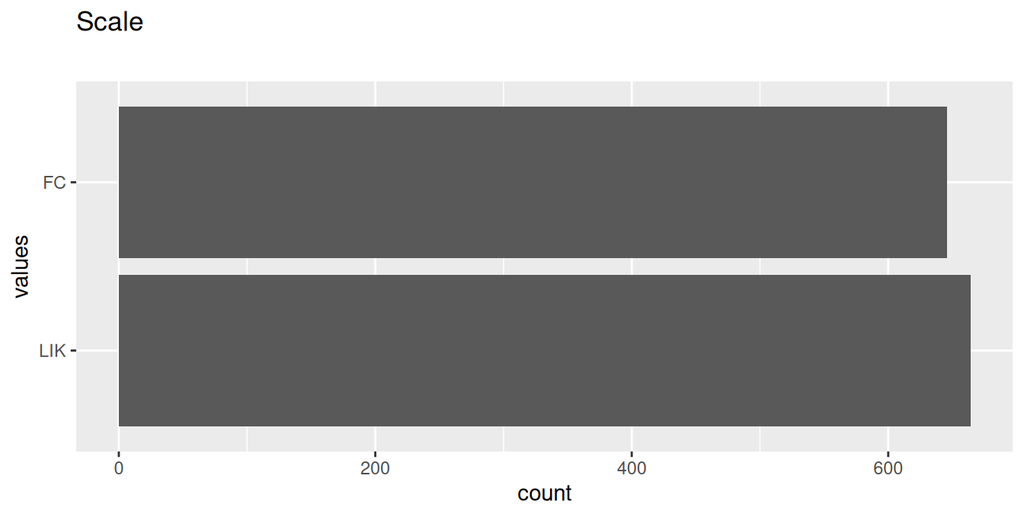

Distribution of values for Scale

0 missing values.

#### Summary statistics

| name | data_type | ordered | value_labels | n_missing | complete_rate | n_unique | top_counts | label |
| --- | --- | --- | --- | --- | --- | --- | --- | --- |
| Scale | factor | FALSE | 1. LIK, 2. FC | 0 | 1 | 2 | LIK: 664, FC: 646 | NA |

### Form

#### Distribution

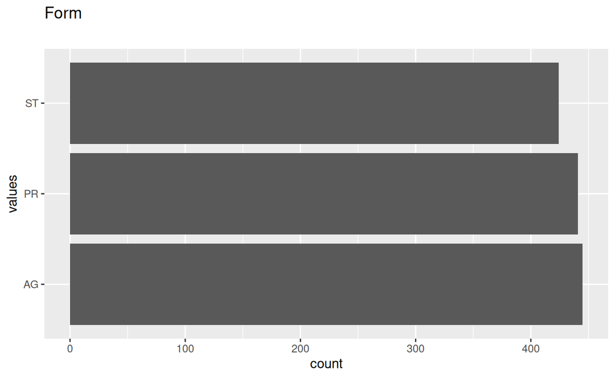

Distribution of values for Form

0 missing values.

#### Summary statistics

| name | data_type | ordered | value_labels | n_missing | complete_rate | n_unique | top_counts | label |
| --- | --- | --- | --- | --- | --- | --- | --- | --- |
| Form | factor | FALSE | 1. AG, 2. PR, 3. ST | 0 | 1 | 3 | AG: 445, PR: 441, ST: 424 | NA |

### edu

#### Distribution

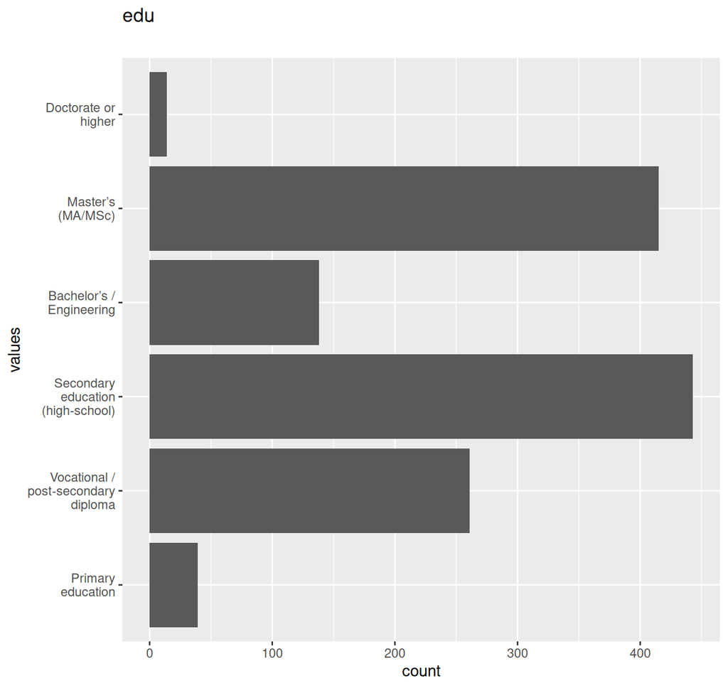

Distribution of values for edu

0 missing values.

#### Summary statistics

| name | data_type | ordered | value_labels | n_missing | complete_rate | n_unique | top_counts | label |
| --- | --- | --- | --- | --- | --- | --- | --- | --- |
| edu | factor | TRUE | 1. Primary education, 2. Vocational / post‑secondary diploma, 3. Secondary education (high‑school), 4. Bachelor’s / Engineering, 5. Master’s (MA/MSc), 6. Doctorate or higher | 0 | 1 | 6 | Sec: 443, Mas: 415, Voc: 261, Bac: 138 | NA |

## Missingness report

| description | KLikert | KBinary | location2 | location3 | KExplOther | sex2 | var_miss | n_miss |
| --- | --- | --- | --- | --- | --- | --- | --- | --- |
| Missing values per variable | 646 | 664 | 1046 | 1088 | 1251 | 1305 | 6000 | 6000 |
| Missing values in 5 variables | 1 | 0 | 0 | 0 | 0 | 0 | 5 | 405 |
| Missing values in 5 variables | 0 | 1 | 0 | 0 | 0 | 0 | 5 | 381 |
| Missing values in 4 variables | 0 | 1 | 1 | 0 | 0 | 0 | 4 | 129 |
| Missing values in 4 variables | 1 | 0 | 1 | 0 | 0 | 0 | 4 | 122 |
| Missing values in 4 variables | 0 | 1 | 0 | 1 | 0 | 0 | 4 | 106 |
| Missing values in 4 variables | 1 | 0 | 0 | 1 | 0 | 0 | 4 | 104 |
| Missing values in 4 variables | 0 | 1 | 0 | 0 | 1 | 0 | 4 | 18 |
| Missing values in 4 variables | 1 | 0 | 0 | 0 | 1 | 0 | 4 | 17 |
| 8 other, less frequent patterns | 5 | 3 | 3 | 2 | 5 | 4 | 26 | 28 |

## Codebook table

| name | label | data_type | ordered | value_labels | n_missing | complete_rate | n_unique | empty | top_counts | min | median | max | mean | sd | whitespace | n_value_labels | hist |
| --- | --- | --- | --- | --- | --- | --- | --- | --- | --- | --- | --- | --- | --- | --- | --- | --- | --- |
| ID | Participant ID | numeric | NA | NA | 0 | 1.0000000 | NA | NA | NA | 1 | 656 | 1310 | 655.5000000 | 378.3087364 | NA | NA | ▇▇▇▇▇ |
| survey_finish_time | Survey completion time (s) | numeric | NA | NA | 0 | 1.0000000 | NA | NA | NA | 109 | 239 | 8483 | 383.2167939 | 648.1144506 | NA | NA | ▇▁▁▁▁ |
| sex | NA | factor | FALSE | 1. Female, 2. Male, 3. Other, 4. Prefer not to say | 0 | 1.0000000 | 4 | NA | Fem: 676, Mal: 629, Oth: 4, Pre: 1 | NA | NA | NA | NA | NA | NA | NA | NA |
| sex2 | Free‑text gender (only if sex = ‘Other’) | character | NA | NA | 1305 | 0.0038168 | 2 | 0 | NA | 7 | NA | 8 | NA | NA | 0 | NA | NA |
| age | Age bin (panel categories) | character | NA | NA | 0 | 1.0000000 | 5 | 0 | NA | 10 | NA | 17 | NA | NA | 0 | NA | NA |
| year | Age in years | numeric | NA | NA | 0 | 1.0000000 | NA | NA | NA | 18 | 45 | 97 | 45.1351145 | 16.4136997 | NA | NA | ▇▇▇▃▁ |
| location | Place of residence (5 levels) | character | NA | NA | 0 | 1.0000000 | 5 | 0 | NA | 4 | NA | 45 | NA | NA | 0 | NA | NA |
| location2 | Residence – mid split (20–49 k vs. 50–99 k) | character | NA | NA | 1046 | 0.2015267 | 2 | 0 | NA | 24 | NA | 24 | NA | NA | 0 | NA | NA |
| location3 | Residence – upper‑mid split (100–200 k vs. 200–500 k) | character | NA | NA | 1088 | 0.1694656 | 2 | 0 | NA | 26 | NA | 26 | NA | NA | 0 | NA | NA |
| KLikert | CEO knew (Likert) | haven_labelled | NA | -3. -3 Strongly disagree, -2. -2, -1. -1, 0. 0, 1. 1, 2. 2, 3. +3 Strongly agree | 646 | 0.5068702 | NA | NA | NA | -3 | 2 | 3 | 1.3614458 | 2.0222193 | NA | 7 | ▂▁▁▂▁▂▂▇ |
| KBinary | CEO knew (forced choice) | numeric | NA | NA | 664 | 0.4931298 | NA | NA | NA | 0 | 1 | 1 | 0.7724458 | 0.4195781 | NA | NA | ▂▁▁▁▇ |
| KBinaryAll | CEO knew – composite (Yes/No/Neither) | character | NA | NA | 0 | 1.0000000 | 3 | 0 | NA | 2 | NA | 7 | NA | NA | 0 | NA | NA |
| KExpl | NA | factor | FALSE | 1. Dyrektor był przekonany, że pomoże środowisku., 2. Dyrektor był przekonany, że stan środowiska się pogorszy., 3. Dyrektor był przekonany, że stan środowiska się polepszy., 4. Dyrektor był przekonan… | 0 | 1.0000000 | 52 | NA | Dyr: 120, Dyr: 120, Dyr: 109, Dyr: 92 | NA | NA | NA | NA | NA | NA | NA | NA |
| KExplSimple | Justification – coded (B/Q/R/O) | character | NA | NA | 0 | 1.0000000 | 4 | 0 | NA | 1 | NA | 1 | NA | NA | 0 | NA | NA |
| KExplOther | Justification (free text for `O(ther)` option) | character | NA | NA | 1251 | 0.0450382 | 59 | 0 | NA | 20 | NA | 243 | NA | NA | 0 | NA | NA |
| KProfits | CEO knew profits increase | haven_labelled | NA | -3. -3 Strongly disagree, -2. -2, -1. -1, 0. 0, 1. 1, 2. 2, 3. +3 Strongly agree | 0 | 1.0000000 | NA | NA | NA | -3 | 3 | 3 | 2.2633588 | 1.1946344 | NA | 7 | ▁▁▁▁▁▁▂▇ |
| Int | Intentionality – ‘intencjonalnie’ | haven_labelled | NA | -3. -3 Strongly disagree, -2. -2, -1. -1, 0. 0, 1. 1, 2. 2, 3. +3 Strongly agree | 0 | 1.0000000 | NA | NA | NA | -3 | 1 | 3 | 0.6320611 | 2.0879540 | NA | 7 | ▅▂▂▅▁▅▅▇ |
| IntUmyślnie | Intentionality – ‘umyślnie’ | haven_labelled | NA | -3. -3 Strongly disagree, -2. -2, -1. -1, 0. 0, 1. 1, 2. 2, 3. +3 Strongly agree | 0 | 1.0000000 | NA | NA | NA | -3 | 1 | 3 | 0.4633588 | 2.2303794 | NA | 7 | ▅▂▂▅▁▃▃▇ |
| IntCelowo | Intentionality – ‘celowo’ | haven_labelled | NA | -3. -3 Strongly disagree, -2. -2, -1. -1, 0. 0, 1. 1, 2. 2, 3. +3 Strongly agree | 0 | 1.0000000 | NA | NA | NA | -3 | 0 | 3 | 0.1106870 | 2.2513811 | NA | 7 | ▇▃▃▆▁▃▃▇ |
| IntŚwiadomie | Intentionality – ‘świadomie’ | haven_labelled | NA | -3. -3 Strongly disagree, -2. -2, -1. -1, 0. 0, 1. 1, 2. 2, 3. +3 Strongly agree | 0 | 1.0000000 | NA | NA | NA | -3 | 1 | 3 | 0.7442748 | 2.2436281 | NA | 7 | ▃▂▂▃▁▂▃▇ |
| Intention | Intention – ‘miał intencję’ | haven_labelled | NA | -3. -3 Strongly disagree, -2. -2, -1. -1, 0. 0, 1. 1, 2. 2, 3. +3 Strongly agree | 0 | 1.0000000 | NA | NA | NA | -3 | 0 | 3 | 0.0259542 | 2.2247853 | NA | 7 | ▇▂▂▆▁▃▃▇ |
| BSądził | Belief – ‘sądził’ | haven_labelled | NA | -3. -3 Strongly disagree, -2. -2, -1. -1, 0. 0, 1. 1, 2. 2, 3. +3 Strongly agree | 0 | 1.0000000 | NA | NA | NA | -3 | 1 | 3 | 0.6221374 | 1.9988457 | NA | 7 | ▃▂▂▇▁▅▃▇ |
| BPrzekonany | Belief – ‘był przekonany’ | haven_labelled | NA | -3. -3 Strongly disagree, -2. -2, -1. -1, 0. 0, 1. 1, 2. 2, 3. +3 Strongly agree | 0 | 1.0000000 | NA | NA | NA | -3 | 1 | 3 | 0.8839695 | 2.0149107 | NA | 7 | ▃▂▂▃▁▃▃▇ |
| Aware | Awareness – ‘był świadomy’ | haven_labelled | NA | -3. -3 Strongly disagree, -2. -2, -1. -1, 0. 0, 1. 1, 2. 2, 3. +3 Strongly agree | 0 | 1.0000000 | NA | NA | NA | -3 | 2 | 3 | 1.4007634 | 1.8929727 | NA | 7 | ▂▁▁▂▁▂▃▇ |
| Reasons | Reasons – ‘miał powody’ | haven_labelled | NA | -3. -3 Strongly disagree, -2. -2, -1. -1, 0. 0, 1. 1, 2. 2, 3. +3 Strongly agree | 0 | 1.0000000 | NA | NA | NA | -3 | 2 | 3 | 1.1473282 | 1.9034297 | NA | 7 | ▂▁▁▃▁▃▃▇ |
| Condition | NA | factor | FALSE | 1. Harm, 2. Help | 0 | 1.0000000 | 2 | NA | Hel: 659, Har: 651 | NA | NA | NA | NA | NA | NA | NA | NA |
| Scale | NA | factor | FALSE | 1. LIK, 2. FC | 0 | 1.0000000 | 2 | NA | LIK: 664, FC: 646 | NA | NA | NA | NA | NA | NA | NA | NA |
| Form | NA | factor | FALSE | 1. AG, 2. PR, 3. ST | 0 | 1.0000000 | 3 | NA | AG: 445, PR: 441, ST: 424 | NA | NA | NA | NA | NA | NA | NA | NA |
| edu | NA | factor | TRUE | 1. Primary education, 2. Vocational / post‑secondary diploma, 3. Secondary education (high‑school), 4. Bachelor’s / Engineering, 5. Master’s (MA/MSc), 6. Doctorate or higher | 0 | 1.0000000 | 6 | NA | Sec: 443, Mas: 415, Voc: 261, Bac: 138 | NA | NA | NA | NA | NA | NA | NA | NA |

**JSON-LD metadata**

The following JSON-LD can be found by search engines, if you share this codebook publicly on the web.

```json
{
  "description": "Cleaned participant‑level data for the Polish replication of the Epistemic Side‑Effect Effect (ESEE).\n\n\n## Table of variables\nThis table contains variable names, labels, and number of missing values.\nSee the complete codebook for more.\n\n|name               |label                                                 | n_missing|\n|:------------------|:-----------------------------------------------------|---------:|\n|ID                 |Participant ID                                        |         0|\n|survey_finish_time |Survey completion time (s)                            |         0|\n|sex                |NA                                                    |         0|\n|sex2               |Free‑text gender (only if sex = ‘Other’)              |      1305|\n|age                |Age bin (panel categories)                            |         0|\n|year               |Age in years                                          |         0|\n|location           |Place of residence (5 levels)                         |         0|\n|location2          |Residence – mid split (20–49 k vs. 50–99 k)           |      1046|\n|location3          |Residence – upper‑mid split (100–200 k vs. 200–500 k) |      1088|\n|KLikert            |CEO knew (Likert)                                     |       646|\n|KBinary            |CEO knew (forced choice)                              |       664|\n|KBinaryAll         |CEO knew – composite (Yes/No/Neither)                 |         0|\n|KExpl              |NA                                                    |         0|\n|KExplSimple        |Justification – coded (B/Q/R/O)                       |         0|\n|KExplOther         |Justification (free text for `O(ther)` option)        |      1251|\n|KProfits           |CEO knew profits increase                             |         0|\n|Int                |Intentionality – ‘intencjonalnie’                     |         0|\n|IntUmyślnie        |Intentionality – ‘umyślnie’                           |         0|\n|IntCelowo          |Intentionality – ‘celowo’                             |         0|\n|IntŚwiadomie       |Intentionality – ‘świadomie’                          |         0|\n|Intention          |Intention – ‘miał intencję’                           |         0|\n|BSądził            |Belief – ‘sądził’                                     |         0|\n|BPrzekonany        |Belief – ‘był przekonany’                             |         0|\n|Aware              |Awareness – ‘był świadomy’                            |         0|\n|Reasons            |Reasons – ‘miał powody’                               |         0|\n|Condition          |NA                                                    |         0|\n|Scale              |NA                                                    |         0|\n|Form               |NA                                                    |         0|\n|edu                |NA                                                    |         0|\n\n### Note\nThis dataset was automatically described using the [codebook R package](https://rubenarslan.github.io/codebook/) (version 0.9.6).",
  "identifier": "doi:10.17605/OSF.IO/6TVNH",
  "citation": "Zaręba, M., Kuś, K., Maćkiewicz, B., & Paprzycka-Hausman, K. (2025). A Replication of the Epistemic Side-Effect Effect in Polish on a Representative Sample. https://doi.org/10.17605/OSF.IO/6TVNH\n",
  "name": "esee",
  "datePublished": "2025-04-23",
  "keywords": ["ID", "survey_finish_time", "sex", "sex2", "age", "year", "location", "location2", "location3", "KLikert", "KBinary", "KBinaryAll", "KExpl", "KExplSimple", "KExplOther", "KProfits", "Int", "IntUmyślnie", "IntCelowo", "IntŚwiadomie", "Intention", "BSądził", "BPrzekonany", "Aware", "Reasons", "Condition", "Scale", "Form", "edu"],
  "@context": "https://schema.org/",
  "@type": "Dataset",
  "variableMeasured": [
    {
      "name": "ID",
      "description": "Participant ID",
      "@type": "propertyValue"
    },
    {
      "name": "survey_finish_time",
      "description": "Survey completion time (s)",
      "@type": "propertyValue"
    },
    {
      "name": "sex",
      "value": "1. Female,\n2. Male,\n3. Other,\n4. Prefer not to say",
      "@type": "propertyValue"
    },
    {
      "name": "sex2",
      "description": "Free‑text gender (only if sex = ‘Other’)",
      "@type": "propertyValue"
    },
    {
      "name": "age",
      "description": "Age bin (panel categories)",
      "@type": "propertyValue"
    },
    {
      "name": "year",
      "description": "Age in years",
      "@type": "propertyValue"
    },
    {
      "name": "location",
      "description": "Place of residence (5 levels)",
      "@type": "propertyValue"
    },
    {
      "name": "location2",
      "description": "Residence – mid split (20–49 k vs. 50–99 k)",
      "@type": "propertyValue"
    },
    {
      "name": "location3",
      "description": "Residence – upper‑mid split (100–200 k vs. 200–500 k)",
      "@type": "propertyValue"
    },
    {
      "name": "KLikert",
      "description": "CEO knew (Likert)",
      "value": "-3. -3 Strongly disagree,\n-2. -2,\n-1. -1,\n0. 0,\n1. 1,\n2. 2,\n3. +3 Strongly agree",
      "maxValue": 3,
      "minValue": -3,
      "@type": "propertyValue"
    },
    {
      "name": "KBinary",
      "description": "CEO knew (forced choice)",
      "@type": "propertyValue"
    },
    {
      "name": "KBinaryAll",
      "description": "CEO knew – composite (Yes/No/Neither)",
      "@type": "propertyValue"
    },
    {
      "name": "KExpl",
      "value": "1. Dyrektor był przekonany, że pomoże środowisku.,\n2. Dyrektor był przekonany, że stan środowiska się pogorszy.,\n3. Dyrektor był przekonany, że stan środowiska się polepszy.,\n4. Dyrektor był przekonany, że wdrożenie programu pomoże środowisku.,\n5. Dyrektor był przekonany, że wdrożenie programu zaszkodzi środowisku.,\n6. Dyrektor był przekonany, że zaszkodzi środowisku.,\n7. Dyrektor miał powody, by sądzić, że pomoże środowisku.,\n8. Dyrektor miał powody, by sądzić, że stan środowiska się pogorszy.,\n9. Dyrektor miał powody, by sądzić, że stan środowiska się polepszy.,\n10. Dyrektor miał powody, by sądzić, że wdrożenie programu pomoże środowisku.,\n11. Dyrektor miał powody, by sądzić, że wdrożenie programu zaszkodzi środowisku.,\n12. Dyrektor miał powody, by sądzić, że zaszkodzi środowisku.,\n13. Dyrektor nie był przekonany, że pomoże środowisku.,\n14. Dyrektor nie był przekonany, że stan środowiska się pogorszy.,\n15. Dyrektor nie był przekonany, że stan środowiska się polepszy.,\n16. Dyrektor nie był przekonany, że wdrożenie programu pomoże środowisku.,\n17. Dyrektor nie był przekonany, że wdrożenie programu zaszkodzi środowisku.,\n18. Dyrektor nie miał powodów, by sądzić, że pomoże środowisku.,\n19. Dyrektor nie miał powodów, by sądzić, że stan środowiska się pogorszy.,\n20. Dyrektor nie miał powodów, by sądzić, że stan środowiska się polepszy.,\n21. Dyrektor nie miał powodów, by sądzić, że wdrożenie programu pomoże środowisku.,\n22. Dyrektor nie miał powodów, by sądzić, że wdrożenie programu zaszkodzi środowisku.,\n23. Dyrektor nie zdawał sobie sprawy, że może pomóc środowisku.,\n24. Dyrektor nie zdawał sobie sprawy, że może zaszkodzić środowisku.,\n25. Dyrektor nie zdawał sobie sprawy, że stan środowiska może się pogorszyć.,\n26. Dyrektor nie zdawał sobie sprawy, że stan środowiska może się polepszyć.,\n27. Dyrektor nie zdawał sobie sprawy, że wdrożenie programu może pomóc środowisku.,\n28. Dyrektor nie zdawał sobie sprawy, że wdrożenie programu może zaszkodzić środowisku.,\n29. Dyrektor zdawał sobie sprawę, że może pomóc środowisku.,\n30. Dyrektor zdawał sobie sprawę, że może zaszkodzić środowisku.,\n31. Dyrektor zdawał sobie sprawę, że stan środowiska może się pogorszyć.,\n32. Dyrektor zdawał sobie sprawę, że stan środowiska może się polepszyć.,\n33. Dyrektor zdawał sobie sprawę, że wdrożenie programu może pomóc środowisku.,\n34. Dyrektor zdawał sobie sprawę, że wdrożenie programu może zaszkodzić środowisku.,\n35. Inne,\n36. Nie było jasne, czy dyrektor był, czy nie był przekonany, że pomoże środowisku.,\n37. Nie było jasne, czy dyrektor był, czy nie był przekonany, że stan środowiska się pogorszy.,\n38. Nie było jasne, czy dyrektor był, czy nie był przekonany, że stan środowiska się polepszy.,\n39. Nie było jasne, czy dyrektor był, czy nie był przekonany, że wdrożenie programu pomoże środowisku.,\n40. Nie było jasne, czy dyrektor był, czy nie był przekonany, że wdrożenie programu zaszkodzi środowisku.,\n41. Nie było jasne, czy dyrektor był, czy nie był przekonany, że zaszkodzi środowisku.,\n42. Nie było jasne, czy dyrektor miał powody, czy nie miał powodów, by sądzić, że pomoże środowisku.,\n43. Nie było jasne, czy dyrektor miał powody, czy nie miał powodów, by sądzić, że stan środowiska się pogorszy.,\n44. Nie było jasne, czy dyrektor miał powody, czy nie miał powodów, by sądzić, że stan środowiska się polepszy.,\n45. Nie było jasne, czy dyrektor miał powody, czy nie miał powodów, by sądzić, że wdrożenie programu pomoże środow,\n46. Nie było jasne, czy dyrektor miał powody, czy nie miał powodów, by sądzić, że wdrożenie programu zaszkodzi środ,\n47. Nie było jasne, czy dyrektor miał powody, czy nie miał powodów, by sądzić, że zaszkodzi środowisku.,\n48. Nie było jasne, czy dyrektor zdawał sobie sprawę, czy nie zdawał sobie sprawy, że może pomóc środowisku.,\n49. Nie było jasne, czy dyrektor zdawał sobie sprawę, czy nie zdawał sobie sprawy, że może zaszkodzić środowisku.,\n50. Nie było jasne, czy dyrektor zdawał sobie sprawę, czy nie zdawał sobie sprawy, że stan środowiska może się polep,\n51. Nie było jasne, czy dyrektor zdawał sobie sprawę, czy nie zdawał sobie sprawy, że wdrożenie programu może pomóc,\n52. Nie było jasne, czy dyrektor zdawał sobie sprawę, czy nie zdawał sobie sprawy, że wdrożenie programu może zaszkod",
      "@type": "propertyValue"
    },
    {
      "name": "KExplSimple",
      "description": "Justification – coded (B/Q/R/O)",
      "@type": "propertyValue"
    },
    {
      "name": "KExplOther",
      "description": "Justification (free text for `O(ther)` option)",
      "@type": "propertyValue"
    },
    {
      "name": "KProfits",
      "description": "CEO knew profits increase",
      "value": "-3. -3 Strongly disagree,\n-2. -2,\n-1. -1,\n0. 0,\n1. 1,\n2. 2,\n3. +3 Strongly agree",
      "maxValue": 3,
      "minValue": -3,
      "@type": "propertyValue"
    },
    {
      "name": "Int",
      "description": "Intentionality – ‘intencjonalnie’",
      "value": "-3. -3 Strongly disagree,\n-2. -2,\n-1. -1,\n0. 0,\n1. 1,\n2. 2,\n3. +3 Strongly agree",
      "maxValue": 3,
      "minValue": -3,
      "@type": "propertyValue"
    },
    {
      "name": "IntUmyślnie",
      "description": "Intentionality – ‘umyślnie’",
      "value": "-3. -3 Strongly disagree,\n-2. -2,\n-1. -1,\n0. 0,\n1. 1,\n2. 2,\n3. +3 Strongly agree",
      "maxValue": 3,
      "minValue": -3,
      "@type": "propertyValue"
    },
    {
      "name": "IntCelowo",
      "description": "Intentionality – ‘celowo’",
      "value": "-3. -3 Strongly disagree,\n-2. -2,\n-1. -1,\n0. 0,\n1. 1,\n2. 2,\n3. +3 Strongly agree",
      "maxValue": 3,
      "minValue": -3,
      "@type": "propertyValue"
    },
    {
      "name": "IntŚwiadomie",
      "description": "Intentionality – ‘świadomie’",
      "value": "-3. -3 Strongly disagree,\n-2. -2,\n-1. -1,\n0. 0,\n1. 1,\n2. 2,\n3. +3 Strongly agree",
      "maxValue": 3,
      "minValue": -3,
      "@type": "propertyValue"
    },
    {
      "name": "Intention",
      "description": "Intention – ‘miał intencję’",
      "value": "-3. -3 Strongly disagree,\n-2. -2,\n-1. -1,\n0. 0,\n1. 1,\n2. 2,\n3. +3 Strongly agree",
      "maxValue": 3,
      "minValue": -3,
      "@type": "propertyValue"
    },
    {
      "name": "BSądził",
      "description": "Belief – ‘sądził’",
      "value": "-3. -3 Strongly disagree,\n-2. -2,\n-1. -1,\n0. 0,\n1. 1,\n2. 2,\n3. +3 Strongly agree",
```

```json
      "maxValue": 3,
      "minValue": -3,
      "@type": "propertyValue"
    },
    {
      "name": "BPrzekonany",
      "description": "Belief – ‘był przekonany’",
      "value": "-3. -3 Strongly disagree,\n-2. -2,\n-1. -1,\n0. 0,\n1. 1,\n2. 2,\n3. +3 Strongly agree",
      "maxValue": 3,
      "minValue": -3,
      "@type": "propertyValue"
    },
    {
      "name": "Aware",
      "description": "Awareness – ‘był świadomy’",
      "value": "-3. -3 Strongly disagree,\n-2. -2,\n-1. -1,\n0. 0,\n1. 1,\n2. 2,\n3. +3 Strongly agree",
      "maxValue": 3,
      "minValue": -3,
      "@type": "propertyValue"
    },
    {
      "name": "Reasons",
      "description": "Reasons – ‘miał powody’",
      "value": "-3. -3 Strongly disagree,\n-2. -2,\n-1. -1,\n0. 0,\n1. 1,\n2. 2,\n3. +3 Strongly agree",
      "maxValue": 3,
      "minValue": -3,
      "@type": "propertyValue"
    },
    {
      "name": "Condition",
      "value": "1. Harm,\n2. Help",
      "@type": "propertyValue"
    },
    {
      "name": "Scale",
      "value": "1. LIK,\n2. FC",
      "@type": "propertyValue"
    },
    {
      "name": "Form",
      "value": "1. AG,\n2. PR,\n3. ST",
      "@type": "propertyValue"
    },
    {
      "name": "edu",
      "value": "1. Primary education,\n2. Vocational / post‑secondary diploma,\n3. Secondary education (high‑school),\n4. Bachelor’s / Engineering,\n5. Master’s (MA/MSc),\n6. Doctorate or higher",
      "@type": "propertyValue"
    }
  ]
}`
```